# Cleaning and preparation of the Youth Surveys

Julia Rohrer

2026-04-07

## Overview

The city of Leipzig conducted Youth Surveys in the years 2010, 2015 and 2023. Here, we are going to start by loading the data and taking an initial look at it.

## Let’s get started with the 2010 Youth Survey

In 2010, the city of Leipzig actually conducted two parallel Youth Surveys. All the following information was taken from the official report: “Jugend in Leipzig – Ergebnisse einer Befragung 2010 [07/2011]” issued by Stadt Leipzig, Amt für Statistik und Wahlen in Kooperation mit dem Amt für Jugend, Familie und Bildung.

### Sampling procedure

First, students between the ages of 12 and 17 were targeted within their respective schools (although students within the same classes who happened to be older were surveyed as well). Second, young people between the ages of 18 and 27 were contacted separately based on registry information, to ensure that young people who already left school were represented as well. Only the first survey has a methodology comparable to the 2015 and 2023 Youth Surveys, so we will exclusively rely on that data and ignore the survey involving older young people.

For the Youth Survey that took part in schools, initially schools were selected, in within those schools all eligible classes were assessed in total. The targeted initial sample size was 3000, which was distributed according to the actual distribution of students between the ages of 12 to 17 in the four types of schools included and the grade levels included (Mittelschule: grades 7 to 10, Gymnasium: grades 7 to 12, Berufs-/Fachoberschule: first and second year, Förderschule: grades 7 to 10). The corresponding schools and classrooms were then picked, prioritising schools who had participated in earlier Youth Surveys for organisational reasons. In total, there were 3459 students in the targeted classes. Of these, a total of 2411 (70%) participated in the Youth Survey and can be found in our data set. The data were collected between October 18th and November 5th 2010.

To my knowledge, no weights were generated for the official report issued by the city.

### Load and clean data

```r
# Read 2010 data
youth2010 <- readRDS("Files/umfschule2010.rds")

# prepare some basic variables
# add year
youth2010$year <- 2010

# schooltype
# existing variable
table(youth2010$`@schultyp`)
```

```
##
##   0   1   2   3
## 681 767 862 101
```

```r
# 0: Mittelschule, secondary school (grade 7 to 10)
# 1: Gymnasium, grammar school (grade 7 to 12)
# 2: Berufs-/Fachoberschule, vocational school (1st and 2nd year)
# 3: Förderschule, special-needs school (grade 7 to 10)

youth2010$schooltype <- NA
youth2010$schooltype[youth2010$`@schultyp` == 0] <- 1 # Mittelschule
youth2010$schooltype[youth2010$`@schultyp` == 1] <- 2 # Gymnasium
youth2010$schooltype[youth2010$`@schultyp` == 2] <- 3 # Berufs-/Fachoberschule
youth2010$schooltype[youth2010$`@schultyp` == 3] <- 4 # Förderschule

# gender
table(youth2010$geschl) # original gender variable
```

```
##
##    1    2
## 1210 1191
```

```r
youth2010$gender <- NA # generate new gender variable
youth2010$gender[youth2010$geschl == 1] <- "male"
youth2010$gender[youth2010$geschl == 2] <- "female"
table(youth2010$gender)
```

```
##
## female   male
##   1191   1210
```

```r
# age
table(youth2010$alter)
```

```
##
##  11  12  13  14  15  16  17  18  19  20  21  22  23  24  25  26  27
##   2 199 431 332 268 297 292 162  99 107  51  42  33  28  18   9   7
```

```r
youth2010$age <- youth2010$alter

# migback
# migration background was assessed by asking respondents
# whether they and their parents were born in Germany
# self born in Germany? if no, which country
table(youth2010$s23ad, youth2010$s23aa, useNA = "always")
```

```
##
##         121  126  129  134  137  140  142  146  150  151  152  158  160  163
##   1       0    0    0    0    0    0    0    0    0    0    0    0    0    0
##   <NA>    2    3    1    1    1    1    3    1    1    1    2    1   24    8
##
##         166  169  170  221  245  326  335  348  351  361  368  386  423  425
##   1       0    0    0    0    0    0    0    0    0    0    0    0    0    0
##   <NA>   21    1    2    1    1    1    1    1    2    1    1    1    7    1
##
##         430  432  434  436  437  438  439  444  450  451  461  475  476  477
##   1       0    0    0    0    0    0    0    0    0    0    0    0    0    0
##   <NA>    2    8    1    1    1   12    1   21    1    1    1    1    1    3
##
##         536  998 <NA>
##   1       0    0 2243
##   <NA>    1    2   18
```

```r
# father born in Germany? if no, which country
table(youth2010$s23bd, youth2010$s23ba, useNA = "always")
```

```
##
##           0  121  122  125  126  129  130  131  132  134  137  140  142  144
##   1       0    0    0    0    0    0    0    0    0    0    0    0    0    0
##   <NA>    4    3    1    3    1    1    1    1    1    1    6    1    3    2
##
##         148  150  151  152  153  154  157  158  159  160  161  163  165  166
##   1       0    0    0    0    0    0    0    0    0    0    0    0    0    0
##   <NA>    1    1    2   10    4    1    2    1    2   31    1   20    4   17
##
##         168  169  170  195  221  223  225  238  248  252  254  262  269  276
##   1       0    0    0    0    0    0    0    0    0    0    0    0    0    0
##   <NA>    2    1    2    1    9    2    1    1    1    4    7    1    1    1
##
##         282  285  287  289  326  332  348  351  361  367  368  423  425  430
##   1       0    0    0    0    0    0    0    0    0    0    0    0    0    0
##   <NA>    1    2    3    1    1    2    1    6    5    1    3    8    3    2
##
##         431  432  434  436  437  438  439  444  445  450  451  458  461  475
##   1       0    0    0    0    0    0    0    0    0    0    0    0    0    0
##   <NA>    1   46    1    6    1   13    1   21    2    1    2    1    2    4
##
##         476  477  479  996  998 <NA>
##   1       0    0    0    0    0 2030
##   <NA>    1    3    1    1   11   63
```

```r
# mother born in Germany? if no, which country
table(youth2010$s23cd, youth2010$s23ca, useNA = "always")
```

```
##
##         121  125  126  129  130  131  134  140  142  146  151  152  155  158
##   1       0    0    0    0    0    0    0    0    0    0    0    0    0    0
##   <NA>    2    5    1    1    2    1    2    1    3    1    2   16    1    1
##
##         159  160  161  163  164  165  166  169  170  223  227  262  289  326
##   1       0    0    0    0    0    0    0    0    0    0    0    0    0    0
##   <NA>    2   29    1   10    2    1   25    1    4    1    1    1    1    1
##
##         327  332  361  423  425  430  432  434  436  437  438  439  444  450
##   1       0    0    0    0    0    0    0    0    0    0    0    0    0    0
##   <NA>    1    1    1   10    1    3   40    1    3    1   12    2   18    1
##
##         451  461  462  470  475  476  477  996  998 <NA>
##   1       0    0    0    0    0    0    0    0    0 2138
##   <NA>    1    1    1    2    1    2    2    1   10   38
```

```r
# always lived in Germany?
table(youth2010$s24a, useNA = "always")
```

```
##
##    1 <NA>
## 2225  186
```

```r
# in Germany since age...
table(youth2010$s24b, useNA = "always")
```

```
##
##    1    2    3    4    5    6    7    8    9   10   11   12   13   14   15   16
##   14   13   12   14   10   12    9    9   10   15   11    5    8    5    3    3
##   18   19 <NA>
##    1    1 2256
```

```r
youth2010$migback <- NA

# Self, father, mother born in Germany
youth2010$migback[!is.na(youth2010$s23ad) & !is.na(youth2010$s23bd) & !is.na(youth2010$s23cd)] <- "none"
# Self born in Germany, father mother not born in Germany
youth2010$migback[!is.na(youth2010$s23ad) & !is.na(youth2010$s23ba) & !is.na(youth2010$s23ca)] <- "both"
# Self born in Germany, father not born in Germany, mother born in Germany
youth2010$migback[!is.na(youth2010$s23ad) & !is.na(youth2010$s23ba) & !is.na(youth2010$s23cd)] <- "father"
# Self born in Germany, father born in Germany, mother not born in Germany
youth2010$migback[!is.na(youth2010$s23ad) & !is.na(youth2010$s23bd) & !is.na(youth2010$s23ca)] <- "mother"
# Self not born in Germany
youth2010$migback[!is.na(youth2010$s23aa)] <- "self"
# If both parents in Germany, assume self is also born in germany
youth2010$migback[!is.na(youth2010$s23bd) & !is.na(youth2010$s23cd)] <- "none"

table(youth2010$migback, useNA = "always")
```

```
##
##   both father mother   none   self   <NA>
##     66    123     35   1983    145     59
```

```r
# Dichotomous indicator of Migration background/German not main language
# we will need this later because in 2015, migration background was
# not assessed in the same manner
youth2010$mig_lang[youth2010$migback == "none"|youth2010$migback == "father"|youth2010$migback == "mother"] <- 0
youth2010$mig_lang[youth2010$migback == "self"|youth2010$migback == "both"] <- 1

table(youth2010$mig_lang, useNA = "always")
```

```
##
##    0    1 <NA>
## 2141  211   59
```

```r
# Satisfaction items
# Students were asked for their satisfaction with various things
# Here, we will recode the items so that higher values indicate more satisfaction
# For all items that are comparable between the 2010, 2015 and 2023 Youth Surveys
youth2010$satis <- 6 - youth2010$s02a
youth2010$satis_money <- 6 - youth2010$s02b
youth2010$satis_friends <- 6 - youth2010$s02c
youth2010$satis_mom <- 6 - youth2010$s02d
youth2010$satis_dad <- 6 - youth2010$s02e
youth2010$satis_leisure <- 6 - youth2010$s02g
youth2010$satis_dwell <- 6 - youth2010$s02h
youth2010$satis_grades <- 6 - youth2010$s02f

table(youth2010$gender, useNA = "always")
```

```
##
## female   male   <NA>
##   1191   1210     10
```

```r
table(youth2010$schooltype, useNA = "always")
```

```
##
##    1    2    3    4 <NA>
##  681  767  862  101    0
```

```r
table(youth2010$migback, useNA = "always")
```

```
##
##   both father mother   none   self   <NA>
##     66    123     35   1983    145     59
```

```r
table(youth2010$satis, useNA = "always")
```

```
##
##    1    2    3    4    5 <NA>
##   28  136  532 1152  551   12
```

```r
# Grade level
table(youth2010$klasse)
```

```
##
##   A   B   C   D   E   F   G   H   I   K   L   M   N
##   5 422 448 310 247  80  44 116 349 165 115  69  41
```

```r
# A: 6, B: 7, C: 8, D: 9, E: 10, F: 11, G: 12
youth2010$grade_level <- NA
youth2010$grade_level[youth2010$klasse == "A"] <- 6
youth2010$grade_level[youth2010$klasse == "B"] <- 7
youth2010$grade_level[youth2010$klasse == "C"] <- 8
youth2010$grade_level[youth2010$klasse == "D"] <- 9
youth2010$grade_level[youth2010$klasse == "E"] <- 10
youth2010$grade_level[youth2010$klasse == "F"] <- 11
youth2010$grade_level[youth2010$klasse == "G"] <- 12
```

### An initial look at the data

```r
# Gender
# Absolute numbers
table(youth2010$gender)
```

```
##
## female   male
##   1191   1210
```

```r
# Proportions
round(prop.table(table(youth2010$gender)), digits = 2)
```

```
##
## female   male
##    0.5    0.5
```

```r
# Age
table(youth2010$age)
```

```
##
##  11  12  13  14  15  16  17  18  19  20  21  22  23  24  25  26  27
##   2 199 431 332 268 297 292 162  99 107  51  42  33  28  18   9   7
```

```r
summary(youth2010$age)
```

```
##    Min. 1st Qu.  Median    Mean 3rd Qu.    Max.    NA's
##   11.00   13.00   15.00   15.83   17.00   27.00      34
```

```r
sd(youth2010$age, na.rm = TRUE)
```

```
## [1] 3.014138
```

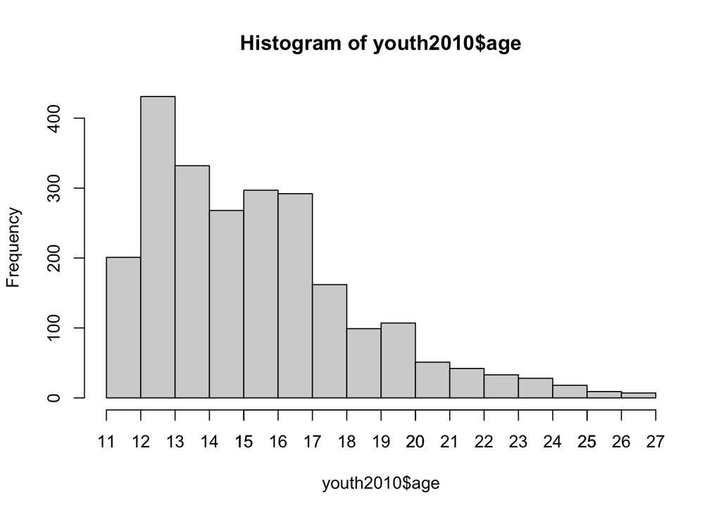

```r
hist(youth2010$age)
axis(1, at = seq(min(youth2010$age, na.rm = TRUE), max(youth2010$age, na.rm = TRUE), by = 1))
```

```r
# School types
table(youth2010$schooltype)
```

```
##
##   1   2   3   4
## 681 767 862 101
```

```r
round(prop.table(table(youth2010$schooltype)), digits = 2)
```

```
##
##    1    2    3    4
## 0.28 0.32 0.36 0.04
```

```r
# 1: Mittelschule, secondary school (grade 7 to 10)
# 2: Gymnasium, grammar school (grade 7 to 12)
# 3: Berufs-/Fachoberschule, vocational school (1st and 2nd year)
# 4: Förderschule, special-needs school (grade 7 to 10)

# Migration background
table(youth2010$migback)
```

```
##
##   both father mother   none   self
##     66    123     35   1983    145
```

```r
round(prop.table(table(youth2010$migback)), digits = 2)
```

```
##
##   both father mother   none   self
##   0.03   0.05   0.01   0.84   0.06
```

```r
# Dichotomous indicator
table(youth2010$mig_lang)
```

```
##
##    0    1
## 2141  211
```

```r
round(prop.table(table(youth2010$mig_lang)), digits = 2)
```

```
##
##    0    1
## 0.91 0.09
```

## 2015 Youth Survey

The next Youth Survey was conducted five years later. The following information was taken from the official report: “Jugend in Leipzig – Ergebnisse einer Befragung 2015 [08/2015]” issued by Stadt Leipzig, Amt für Statistik und Wahlen in Kooperation mit dem Amt für Jugend, Familie und Bildung.

### Sampling procedure

In 2015, only one survey took place, targeting students within their respective schools.

To my knowledge, no weights were generated for the official report issued by the city.

### Load and clean data

```r
# Read 2015 data
youth2015 <- read_spss("Files/jugend2015.sav")

# prepare some basic variables
# add year
youth2015$year <- 2015

# schooltype
# existing variable
table(youth2015$schulart)
```

```
##
##   1   2   3   4
## 950 660 570  71
```

```r
# 1: Gymnasium
# 2: Oberschule
# 3: Berufs-/Fachoberschule
# 4: Förderschule

youth2015$schooltype <- NA
youth2015$schooltype[youth2015$schulart == 2] <- 1 # Mittelschule/Oberschule
youth2015$schooltype[youth2015$schulart == 1] <- 2 # Gymnasium
youth2015$schooltype[youth2015$schulart == 3] <- 3 # Berufs-/Fachoberschule
youth2015$schooltype[youth2015$schulart == 4] <- 4 # Förderschule

# gender
table(youth2015$geschlecht)
```

```
##
##    1    2
## 1029 1207
```

```r
youth2015$gender <- NA
youth2015$gender[youth2015$geschlecht == 1] <- "male"
youth2015$gender[youth2015$geschlecht == 2] <- "female"
table(youth2015$gender, youth2015$geschlecht)
```

```
##
##             1    2
##   female    0 1207
##   male   1029    0
```

```r
# age
table(youth2015$alter)
```

```
##
##  12  13  14  15  16  17  18  19  20  21  22  23  24  25  26  27  28  29  30  32
##  36 306 405 417 353 333 168  67  42  29  18  17  13  10   4   7   2   3   4   4
##  33  34  35  38  40
##   2   2   2   1   1
```

```r
youth2015$age <- youth2015$alter

# migback
# in 2015, no detailed information on migration background was collected
# but only information on the main language spoken at home
# according to personal communications, this decision was made
# (1) to increase comparability with other youth surveys and
# (2) to ask in a more child-friendly manner
youth2015$migback <- NA

table(youth2015$f19)
```

```
##
##    1    2
## 2029  208
```

```r
youth2015$german_at_home <- ifelse(youth2015$f19 == 1, 1, 0)
table(youth2015$german_at_home)
```

```
##
##    0    1
##  208 2029
```

```r
youth2015$mig_lang <- 1 - youth2015$german_at_home

# Satisfaction items
# Students were asked for their satisfaction with various things
# Here, we will recode the items so that higher values indicate more satisfaction
# For all items that are comparable between the 2010, 2015 and 2023 Youth Surveys
youth2015$satis <- 6 - youth2015$f02a
youth2015$satis_money <- 6 - youth2015$f02b
youth2015$satis_friends <- 6 - youth2015$f02c
youth2015$satis_mom <- 6 - youth2015$f02d
youth2015$satis_dad <- 6 - youth2015$f02e
youth2015$satis_leisure <- 6 - youth2015$f02g
youth2015$satis_dwell <- 6 - youth2015$f02h
youth2015$satis_grades <- 6 - youth2015$f02f

# Grade-level
table(youth2015$Klasse)
```

```
##
##   1   2   3   4   5   7   8   9  11
## 360 410 465 251 195 297 142 101  30
```

```r
# 1: 7, 2: 8, 3: 9, 4: 10, 5: 11, 6: 12
youth2015$grade_level <- NA
youth2015$grade_level[youth2015$Klasse == 1] <- 7
youth2015$grade_level[youth2015$Klasse == 2] <- 8
youth2015$grade_level[youth2015$Klasse == 3] <- 9
youth2015$grade_level[youth2015$Klasse == 4] <- 10
youth2015$grade_level[youth2015$Klasse == 5] <- 11
youth2015$grade_level[youth2015$Klasse == 6] <- 12
```

### An initial look at the data

```r
# Gender
# Absolute numbers
table(youth2015$gender)
```

```
##
## female   male
##   1207   1029
```

```r
# Proportions
round(prop.table(table(youth2015$gender)), digits = 2)
```

```
##
## female   male
##   0.54   0.46
```

```r
# Age
table(youth2015$age)
```

```
##
##  12  13  14  15  16  17  18  19  20  21  22  23  24  25  26  27  28  29  30  32
##  36 306 405 417 353 333 168  67  42  29  18  17  13  10   4   7   2   3   4   4
##  33  34  35  38  40
##   2   2   2   1   1
```

```r
summary(youth2015$age)
```

```
##    Min. 1st Qu.  Median    Mean 3rd Qu.    Max.    NA's
##    12.0    14.0    15.0    15.9    17.0    40.0       9
```

```r
sd(youth2015$age, na.rm = TRUE)
```

```
## [1] 2.857354
```

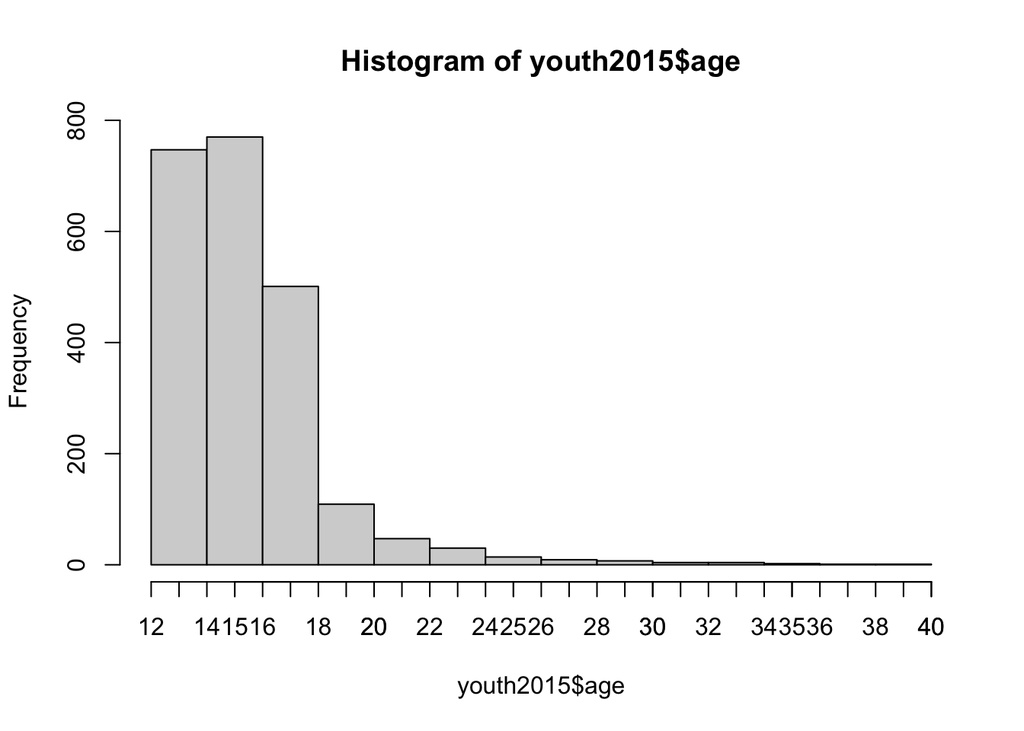

```r
hist(youth2015$age)
axis(1, at = seq(min(youth2015$age, na.rm = TRUE), max(youth2015$age, na.rm = TRUE), by = 1))
```

```r
# School types
table(youth2015$schooltype)
```

```
##
##   1   2   3   4
## 660 950 570  71
```

```r
round(prop.table(table(youth2015$schooltype)), digits = 2)
```

```
##
##    1    2    3    4
## 0.29 0.42 0.25 0.03
```

```r
# 1: Mittelschule, secondary school (grade 7 to 10)
# 2: Gymnasium, grammar school (grade 7 to 11)
# 3: Berufs-/Fachoberschule, vocational school (1st, 2nd, 3rd year)
# 4: Förderschule, special-needs school (grade 7 to 10)

# Migration background
# not assessed

# And the language at home
table(youth2015$mig_lang)
```

```
##
##    0    1
## 2029  208
```

```r
round(prop.table(table(youth2015$mig_lang)), digits = 2)
```

```
##
##    0    1
## 0.91 0.09
```

## 2023 Youth Survey

The next Youth Survey was supposed to happen in 2020 but was delayed by 3 years due to the COVID-19 pandemic. The following information was taken from the official report: “Jugend in Leipzig 2023” issued by Stadt Leipzig, Amt für Statistik und Wahlen/Amt für Jugend un Familie/Amt für Schule.

### Sampling procedure

In 2023, the sampling procedures were adjusted. Instead of first selecting schools and then assessing the relevant classrooms within those schools, classrooms were drawn across schools. This change was implemented to increase the variability in the data and improve the representativeness of the results. Furthermore, students from special-needs schools were intentionally oversampled, and weights were generated to account for this overrepresentation.

The data were collected between March 1st and April 28th 2023, which means that students in grade 12 at Gymnasium could be included. Approximately 65% of students filled out the questionnaire on a tablet as opposed to on paper.

### Load and clean data

```r
# Read 2023 data
library(haven)
youth2023 <- readRDS("Files/jugend2023.rds")

# prepare some basic variables
# add year
youth2023$year <- 2023

# schooltype
# existing variable
table(youth2023$schulart)
```

```
##
##    1    2    3    4    5
##  491  474  144 1244  683
```

```r
# 1: Beruchsfachschule
# 2: Berufsschule
# 3: Förderschule
# 4: Gymnasium
# 5: Oberschule

youth2023$schooltype <- NA
youth2023$schooltype[youth2023$schulart == 5] <- 1 # Mittelschule/Oberschule
youth2023$schooltype[youth2023$schulart == 4] <- 2 # Gymnasium
youth2023$schooltype[youth2023$schulart == 1 | youth2023$schulart == 2] <- 3 # Berufs-/Fachoberschule
youth2023$schooltype[youth2023$schulart == 3] <- 4 # Förderschule

# gender
table(youth2023$geschl)
```

```
##
##    1    2    3
## 1394 1520   83
```

```r
youth2023$gender <- NA
youth2023$gender[youth2023$geschl == 1] <- "male"
youth2023$gender[youth2023$geschl == 2] <- "female"
youth2023$gender[youth2023$geschl == 3] <- "diverse"
table(youth2023$gender, youth2023$geschl)
```

```
##
##              1    2    3
##   diverse    0    0   83
##   female     0 1520    0
##   male    1394    0    0
```

```r
# age
table(youth2023$alter)
```

```
##
##  12  13  14  15  16  17  18  19  20  21  22  23  24  25  26  27  28  29  30  31
## 118 396 446 421 366 295 274 161 125  99  76  51  28  19  20  16   8   5   4   3
##  32  33  34  35  36  37  38  39  41  42  43  44  45  46  49
##   3   4   5   3   4   3   2   2   2   2   1   2   1   1   1
```

```r
youth2023$age <- youth2023$alter

# migback
# country of birth, Germany or other
table(youth2023$staat_geb_person) # self
```

```
##
##    1    2
## 2728  235
```

```r
table(youth2023$staat_geb_vater) # father
```

```
##
##    1    2
## 2437  487
```

```r
table(youth2023$staat_geb_mutter) # mother
```

```
##
##    1    2
## 2539  444
```

```r
youth2023$migback <- NA
# Self, father, mother born in Germany
youth2023$migback[youth2023$staat_geb_person == 1 & youth2023$staat_geb_vater == 1 & youth2023$staat_geb_mutter == 1] <- "none"
# Self born in Germany, father mother not born in Germany
youth2023$migback[youth2023$staat_geb_person == 1 & youth2023$staat_geb_vater == 2 & youth2023$staat_geb_mutter == 2] <- "both"
# Self born in Germany, father not born in Germany, mother born in Germany
youth2023$migback[youth2023$staat_geb_person == 1 & youth2023$staat_geb_vater == 2 & youth2023$staat_geb_mutter == 1] <- "father"
# Self born in Germany, father born in Germany, mother not born in Germany
youth2023$migback[youth2023$staat_geb_person == 1 & youth2023$staat_geb_vater == 1 & youth2023$staat_geb_mutter == 2] <- "mother"
# Self not born in Germany
youth2023$migback[youth2023$staat_geb_person == 2] <- "self"


# If both parents in Germany, assume self is also born in germany
# Only relevant for missing reports of own country
youth2023$migback[youth2023$staat_geb_vater == 1 & youth2023$staat_geb_mutter == 1] <- "none"
table(youth2023$migback, useNA = "always")
```

```
##
##   both father mother   none   self   <NA>
##    146    133     84   2337    221    115
```

```r
# Dichotomous variable
youth2023$mig_lang <- NA
youth2023$mig_lang[youth2023$migback == "none"|youth2023$migback == "mother"|youth2023$migback == "father"] <- 0
youth2023$mig_lang[youth2023$migback == "self"|youth2023$migback == "both"] <- 1

table(youth2023$mig_lang, useNA = "always")
```

```
##
##    0    1 <NA>
## 2554  367  115
```

```r
# Satisfaction items
# Students were asked for their satisfaction with various things
# Here, we will recode the items so that higher values indicate more satisfaction
# For all items that are comparable between the 2010, 2015 and 2023 Youth Surveys
youth2023$satis <- 6 - youth2023$f02a
youth2023$satis_money <- 6 - youth2023$f02b
youth2023$satis_friends <- 6 - youth2023$f02c
youth2023$satis_mom <- 6 - youth2023$f02d
youth2023$satis_dad <- 6 - youth2023$f02e
youth2023$satis_leisure <- 6 - youth2023$f02h
youth2023$satis_dwell <- 6 - youth2023$f02i
youth2023$satis_grades <- 6 - youth2023$f02f

# Grade-level
table(youth2023$klassenstufe)
```

```
##
##   1   2   3   4   5   6   7   8   9
## 531 477 432 345 179 129 540 269 134
```

```r
# 1: 7, 2: 8, 3: 9, 4: 10, 5: 11, 6: 12
youth2023$grade_level <- NA
youth2023$grade_level[youth2023$klassenstufe == 1] <- 7
youth2023$grade_level[youth2023$klassenstufe == 2] <- 8
youth2023$grade_level[youth2023$klassenstufe == 3] <- 9
youth2023$grade_level[youth2023$klassenstufe == 4] <- 10
youth2023$grade_level[youth2023$klassenstufe == 5] <- 11
youth2023$grade_level[youth2023$klassenstufe == 6] <- 12
```

### An initial look at the data

```r
# Gender
# Absolute numbers
table(youth2023$gender)
```

```
##
## diverse  female    male
##      83    1520    1394
```

```r
# Proportions
round(prop.table(table(youth2023$gender)), digits = 2)
```

```
##
## diverse  female    male
##    0.03    0.51    0.47
```

```r
# Age
table(youth2023$age)
```

```
##
##  12  13  14  15  16  17  18  19  20  21  22  23  24  25  26  27  28  29  30  31
## 118 396 446 421 366 295 274 161 125  99  76  51  28  19  20  16   8   5   4   3
##  32  33  34  35  36  37  38  39  41  42  43  44  45  46  49
##   3   4   5   3   4   3   2   2   2   2   1   2   1   1   1
```

```r
summary(youth2023$age)
```

```
##    Min. 1st Qu.  Median    Mean 3rd Qu.    Max.    NA's
##   12.00   14.00   16.00   16.66   18.00   49.00      69
```

```r
sd(youth2023$age, na.rm = TRUE)
```

```
## [1] 3.977811
```

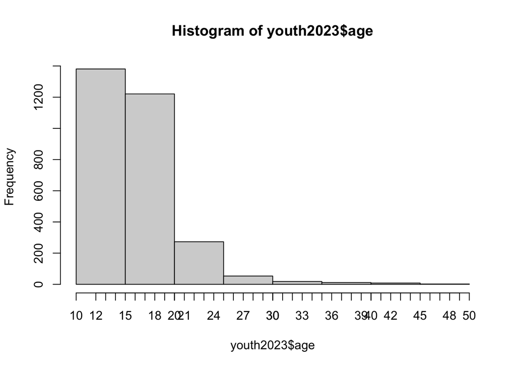

```r
hist(youth2023$age)
axis(1, at = seq(min(youth2023$age, na.rm = TRUE), max(youth2023$age, na.rm = TRUE), by = 1))
```

```r
# School types
table(youth2023$schooltype)
```

```
##
##    1    2    3    4
##  683 1244  965  144
```

```r
round(prop.table(table(youth2023$schooltype)), digits = 2)
```

```
##
##    1    2    3    4
## 0.22 0.41 0.32 0.05
```

```r
# 1: Mittelschule, secondary school (grade 7 to 10)
# 2: Gymnasium, grammar school (grade 7 to 11)
# 3: Berufs-/Fachoberschule, vocational school (1st, 2nd, 3rd year)
# 4: Förderschule, special-needs school (grade 7 to 10)

# Migration background
table(youth2023$migback)
```

```
##
##   both father mother   none   self
##    146    133     84   2337    221
```

```r
round(prop.table(table(youth2023$migback)), digits = 2)
```

```
##
##   both father mother   none   self
##   0.05   0.05   0.03   0.80   0.08
```

```r
# And the assumed language at home
table(youth2023$mig_lang)
```

```
##
##    0    1
## 2554  367
```

```r
round(prop.table(table(youth2023$mig_lang)), digits = 2)
```

```
##
##    0    1
## 0.87 0.13
```

```r
# And here are the weights
summary(youth2023$wph)
```

```
##    Min. 1st Qu.  Median    Mean 3rd Qu.    Max.
##  0.3326  0.7908  0.8463  0.9335  1.1023  1.4810
```

```r
# Reverse-engineering what went into the weights
summary(lm(wph ~ as.factor(gender)*as.factor(schooltype)*as.factor(klassenstufe), data = youth2023))$r.squared
```

```
## [1] 0.9998635
```

```r
# As far as I can tell, the weights are a function of gender, schooltype and grade level (except for some minor deviations, which may be miscodings or result from assigning gender diverse students to one of the two groups)
```

## Additional variables

### Unique classroom IDs

Generate a variable that identifies each unique classroom in the data.

```r
# youth2010: schule, klasse A/B/C
table(youth2010$klasse)
```

```
##
##   A   B   C   D   E   F   G   H   I   K   L   M   N
##   5 422 448 310 247  80  44 116 349 165 115  69  41
```

```r
# I think Klasse within Schule identifies unique classrooms
youth2010$unique_classroom <- paste0(youth2010$schule, youth2010$klasse)
table(youth2010$unique_classroom)
```

```
##
##  0B  0C  0E 10C 10D 10E 11B  1B  1C  1D 20B 20C 20D 20E 20F 21B 21C 22B 22C 22D
##  11   7  29  39  33  37  23  12  13  16  20  22  13  18  46  25  21  18  20  15
## 22E 22F 22G 23B 23C 23D 23E 23G 24B 24C 24D 24E 24F 24G 25B 25C 25D 25E 25G 26B
##  20   9   4  37  49  36   1  19  19  22  24  11  18  15  15  22  18  16   6  21
## 26C 26D 27B 27C 28B 28C  2B  2C  2D  2E 30I 31F 31H 31L 32H 32I 32K 33H 33I 33K
##  17  19  36  45  24  26  15  17   8  24   6   7  15  25  13  42  57  18  48  41
## 34I 35H 36L 37H 37I 38L 38M 39I  3B  3C  3D  3E 40I 40L 40M 40N 41H 41I 41K 42H
##  41  17  29  32  47  41  21  78  19  11  16  18  27  20  26  41   5  38  67  16
## 42I 42M  4B  4C  4D  4E 50B 50C 50D 51C 51D 51E 53A 53B 53C 54B 54C 54D 54E  5B
##  22  22  24  15  18  14  10  10   6   5  25  10   5   6   6   5   3   4   6  23
##  5C  6B  6C  6D  7B  7C  7D  7E  8B  8D  9B  9C  9D  9E
##  23   8  15  12  20  21  20  16  11  13  20  19  14  27
```

```r
length(unique(youth2010$unique_classroom))
```

```
## [1] 114
```

```r
# 114 classrooms in
#table(youth2010$schule)
length(unique(youth2010$schule)) # 38 schools
```

```
## [1] 38
```

```r
str(youth2010$schule) # no labels attached
```

```
##  num [1:2411] 53 53 53 53 53 1 1 1 1 1 ...
##  - attr(*, "label")= chr "Schule:"
##  - attr(*, "format.spss")= chr "F2.0"
```

```r
# generate IDs that contain the year
youth2010$school <- paste("2010", youth2010$schule, sep = "_")
youth2010$unique_classroom <- paste("2010", youth2010$unique_classroom, sep = "_")

# youth2015
# kennung, schulart, ortsteil, Klasse
# class from 1 to 11
length(unique(youth2015$kennung))
```

```
## [1] 114
```

```r
# 114 distinct values -- these are most likely classrooms?
# this variable is schulart + ortsteil + klasse and should identify unique classrooms
# schulart + ortsteil should uniquely identify schools
# only exception: documentation looks like there are two Berufs/fachoberschulen
# in 02 (Zentrum-Suedost)
youth2015$school <- paste0("2015_", youth2015$ortsteil, youth2015$schulart)
table(youth2015$school)
```

```
##
##  2015_131  2015_142  2015_212  2015_224   2015_23  2015_233  2015_271  2015_301
##       102        47        65        19         9        46       107        94
##  2015_304  2015_323  2015_401  2015_402   2015_41  2015_412  2015_432   2015_52
##        18       103       131        64       128        53        62        58
##  2015_521  2015_532  2015_533  2015_543  2015_643  2015_651  2015_652  2015_654
##        42        74        86        11        54       123        66        34
##  2015_703  2015_711  2015_723  2015_742  2015_812  2015_901  2015_902  2015_912
##        48       116        51        49        40       107        34        48
##  2015_933 2015_NANA
##       162         4
```

```r
youth2015$school[youth2015$school == "NANA"] <- NA
length(unique(youth2015$school)) # 34 schools
```

```
## [1] 34
```

```r
youth2015$unique_classroom <- paste(2015, youth2015$kennung, sep = "_")

# youth2023
names(youth2023)
```

```
##   [1] "rawid"                    "pseudonym"
##   [3] "password"                 "language"
##   [5] "source"                   "filename"
##   [7] "filenames"                "zeit"
##   [9] "duration_seconds"         "f01a"
##  [11] "f01b"                     "f01c"
##  [13] "f01d"                     "f01e"
##  [15] "f01f"                     "f01g"
##  [17] "f01h"                     "f01i"
##  [19] "f01j"                     "f01k"
##  [21] "f01l"                     "f01m"
##  [23] "f01n"                     "f01o"
##  [25] "f02a"                     "f02b"
##  [27] "f02c"                     "f02d"
##  [29] "f02e"                     "f02f"
```

[output cut: 313 more lines]

```r
# klassenstufe, schulart, schule_amt51, klasse_amt51, schulart
#table(youth2023$schule_amt51, useNA = "always")
#table(youth2023$klasse_amt51, useNA = "always")
youth2023$test <- paste0("2023_", youth2023$schule_amt51, youth2023$klasse_amt51)
length(unique(youth2023$test)) # 168 -- these must identify unique classrooms
```

```
## [1] 168
```

```r
youth2023$unique_classroom <- youth2023$test
youth2023$school <- paste0("2023_", youth2023$schule_amt51)
```

### Source variable

In 2023, some students answered the survey on tablets. Let’s generate a source variable for the other years as well (everybody was assessed on paper).

```r
# mode variable
youth2010$source <- "paper"
youth2015$source <- "paper"
```

### Match schools across years

Generate a variable that identifies each identifies identical schools across years.

```r
mapping <- read.csv("Mapping_schools.csv", sep = ";")


# 2010
mapping_2010 <- mapping[mapping$Year == 2010,]
names(mapping_2010)[names(mapping_2010) == "Code"] <- "schule"

mapping_2010 <- mapping_2010[, c("schule", "school_id")]
youth2010 <- merge(youth2010, mapping_2010, by = "schule")
# all successfully matched


# 2015
library(haven)
youth2015_school <- read_spss("Files/jugend2015Schule.sav")
mapping_2015 <- mapping[mapping$Year == 2015,]

# First three numbers of kennung identify schools
youth2015_school$schule <- substr(youth2015_school$kennung, 1, 3)

names(mapping_2015)[names(mapping_2015) == "Code"] <- "schule"

mapping_2015 <- mapping_2015[, c("schule", "school_id")]
youth2015_school <- merge(youth2015_school, mapping_2015, by = "schule", all.x = TRUE)

youth2015_school <- youth2015_school[, c("rawid", "school_id")]
youth2015 <- merge(youth2015, youth2015_school, by = "rawid", all.x = TRUE)
rm(youth2015_school)


# 2023: Here, we do have a proper variable
# in the main dataset, containing all names
mapping_2023 <- mapping[mapping$Year == 2023,]
names(mapping_2023)[names(mapping_2023) == "Name"] <- "schule_amt51"
mapping_2023 <- mapping_2023[, c("schule_amt51", "school_id")]

youth2023 <- merge(youth2023, mapping_2023, by = "schule_amt51", all.x = TRUE)
table(youth2023[is.na(youth2023$school_id), "schule_amt51"])
```

```
##
##                                  Förderzentrum FS Sprache "Käthe Kollwitz"
##                                                                          7
## Ruth-Pfau-Schule, BSZ für Gesundheit und Sozialwesen der Stadt Leipzig\r\n
##                                                                         89
```

```r
# Two schools have not been successfully matched due to special characters in their names

# Manually fix those
youth2023$school_id[youth2023$schule_amt51 == "Förderzentrum FS Sprache \"Käthe Kollwitz\""] <- 35
youth2023$school_id[youth2023$schule_amt51 == "Ruth-Pfau-Schule, BSZ für Gesundheit und Sozialwesen der Stadt Leipzig\r\n"] <- 29
```

## Combined dataframe and inclusion criteria

Let’s create one dataframe for everything we will need later.

```r
# Add unique ids
intersect(youth2010$pnum, youth2015$rawid)
```

```
## numeric(0)
```

```r
intersect(youth2010$pnum, youth2023$rawid)
```

```
## numeric(0)
```

```r
intersect(youth2023$rawid, youth2015$rawid)
```

```
## numeric(0)
```

```r
# none of these values intersect, so we can use them
youth2010$id <- youth2010$pnum
youth2015$id <- youth2015$rawid
youth2023$id <- youth2023$rawid


vars <- c("id", "year", "schooltype", "gender", "age", "mig_lang", "migback",
          "satis", "satis_money", "satis_friends", "satis_mom", "satis_dad",
          "satis_leisure", "satis_dwell", "satis_grades", "school", "unique_classroom", "school_id", "source", "grade_level")

combined <- rbind(youth2010[, vars], youth2015[, vars], youth2023[, vars])

# Anonymize unique_classrooms
combined$unique_classroom <- as.factor(combined$unique_classroom)
combined$unique_classroom <- factor(combined$unique_classroom,
                                     levels = levels(combined$unique_classroom),
                                     labels = seq_along(levels(combined$unique_classroom)))


table(youth2010$gender)
```

```
##
## female   male
##   1191   1210
```

```r
table(youth2015$gender)
```

```
##
## female   male
##   1207   1029
```

```r
table(youth2023$gender)
```

```
##
## diverse  female    male
##      83    1520    1394
```

```r
combined_original <- combined

##################
# Numbers included in Table 1: Data set
##################
# Total n per year
table(combined_original$year)
```

```
##
## 2010 2015 2023
## 2411 2255 3036
```

```r
# Classrooms per year
length(unique(combined_original$unique_classroom[combined_original$year == 2010]))
```

```
## [1] 114
```

```r
length(unique(combined_original$unique_classroom[combined_original$year == 2015]))
```

```
## [1] 114
```

```r
length(unique(combined_original$unique_classroom[combined_original$year == 2023]))
```

```
## [1] 168
```

```r
# Schools per year
length(unique(combined_original$school[combined_original$year == 2010]))
```

```
## [1] 38
```

```r
length(unique(combined_original$school_id[combined_original$year == 2015]))
```

```
## [1] 31
```

```r
length(unique(combined_original$school[combined_original$year == 2023]))
```

```
## [1] 64
```

```r
# Schooltype
round(prop.table(table(combined_original$schooltype[combined_original$year == 2010], useNA = "always")), 2)
```

```
##
##    1    2    3    4 <NA>
## 0.28 0.32 0.36 0.04 0.00
```

```r
round(prop.table(table(combined_original$schooltype[combined_original$year == 2015], useNA = "always")), 2)
```

```
##
##    1    2    3    4 <NA>
## 0.29 0.42 0.25 0.03 0.00
```

```r
round(prop.table(table(combined_original$schooltype[combined_original$year == 2023], useNA = "always")), 2)
```

```
##
##    1    2    3    4 <NA>
## 0.22 0.41 0.32 0.05 0.00
```

```r
# Gender
round(prop.table(table(combined_original$gender[combined_original$year == 2010], useNA = "always")), 2)
```

```
##
## female   male   <NA>
##   0.49   0.50   0.00
```

```r
round(prop.table(table(combined_original$gender[combined_original$year == 2015], useNA = "always")), 2)
```

```
##
## female   male   <NA>
##   0.54   0.46   0.01
```

```r
round(prop.table(table(combined_original$gender[combined_original$year == 2023], useNA = "always")), 2)
```

```
##
## diverse  female    male    <NA>
##    0.03    0.50    0.46    0.01
```

```r
# Age
combined_original$age[combined_original$age <= 11] <- 11
combined_original$age[combined_original$age >= 19] <- 19

round(prop.table(table(combined_original$age[combined_original$year == 2010], useNA = "always")), 2)
```

```
##
##   11   12   13   14   15   16   17   18   19 <NA>
## 0.00 0.08 0.18 0.14 0.11 0.12 0.12 0.07 0.16 0.01
```

```r
round(prop.table(table(combined_original$age[combined_original$year == 2015], useNA = "always")), 2)
```

```
##
##   12   13   14   15   16   17   18   19 <NA>
## 0.02 0.14 0.18 0.18 0.16 0.15 0.07 0.10 0.00
```

```r
round(prop.table(table(combined_original$age[combined_original$year == 2023], useNA = "always")), 2)
```

```
##
##   12   13   14   15   16   17   18   19 <NA>
## 0.04 0.13 0.15 0.14 0.12 0.10 0.09 0.21 0.02
```

```r
# Mig
round(prop.table(table(combined_original$mig_lang[combined_original$year == 2010], useNA = "always")), 2)
```

```
##
##    0    1 <NA>
## 0.89 0.09 0.02
```

```r
round(prop.table(table(combined_original$mig_lang[combined_original$year == 2015], useNA = "always")), 2)
```

```
##
##    0    1 <NA>
## 0.90 0.09 0.01
```

```r
round(prop.table(table(combined_original$mig_lang[combined_original$year == 2023], useNA = "always")), 2)
```

```
##
##    0    1 <NA>
## 0.84 0.12 0.04
```

```r
# Exclusion criteria/filter
# Reporting a different gender was not possible in 2010 and 2015
# We thus cannot compare the gender diverse students in 2023 to gender diverse students in earlier years
# Which is why we unfortunately have to exclude them for the present purposes
combined$gender[combined$gender == "diverse"] <- NA

# only keep known gender
combined <- combined[!is.na(combined$gender),]

# known migback
combined <- combined[!is.na(combined$mig_lang),]

# known age
combined <- combined[!is.na(combined$age),]

# known schooltype
combined <- combined[!is.na(combined$schooltype),]

# known outcome
combined <- combined[!is.na(combined$satis),]


combined$gender <- as.factor(combined$gender)
combined$school <- as.factor(combined$school)
combined$unique_classroom <- as.factor(combined$unique_classroom)

# Limit age range
combined <- combined[combined$age >= 12 & combined$age <= 18,]

# Generate a copy with all school types that we will need for something else
combined_all_schooltypes <- combined

# Main analysis sample
combined <- combined[combined$schooltype == 1 | combined$schooltype == 2,]
table(combined$age)
```

```
##
##   12   13   14   15   16   17   18
##  336 1051 1066  973  727  438  173
```

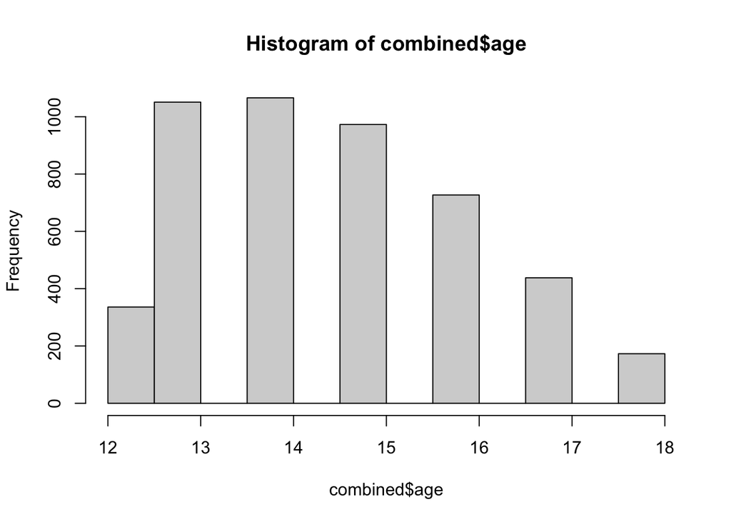

```r
hist(combined$age)
```

```r
# Standardize the outcome across everyone
combined$satis_std <- scale(combined$satis)

##################
# Numbers included in Table 1: Analysis
##################
# Total n per year
table(combined$year)
```

```
##
## 2010 2015 2023
## 1383 1578 1803
```

```r
# Classrooms per year
length(unique(combined$unique_classroom[combined$year == 2010]))
```

```
## [1] 73
```

```r
length(unique(combined$unique_classroom[combined$year == 2015]))
```

```
## [1] 84
```

```r
length(unique(combined$unique_classroom[combined$year == 2023]))
```

```
## [1] 110
```

```r
# Schools per year
length(unique(combined$school[combined$year == 2010]))
```

```
## [1] 21
```

```r
length(unique(combined$school[combined$year == 2015]))
```

```
## [1] 21
```

```r
length(unique(combined$school[combined$year == 2023]))
```

```
## [1] 33
```

```r
# Schooltype
round(prop.table(table(combined$schooltype[combined$year == 2010], useNA = "always")), 2)
```

```
##
##    1    2 <NA>
## 0.46 0.54 0.00
```

```r
round(prop.table(table(combined$schooltype[combined$year == 2015], useNA = "always")), 2)
```

```
##
##    1    2 <NA>
## 0.41 0.59 0.00
```

```r
round(prop.table(table(combined$schooltype[combined$year == 2023], useNA = "always")), 2)
```

```
##
##    1    2 <NA>
## 0.35 0.65 0.00
```

```r
# Gender
round(prop.table(table(combined$gender[combined$year == 2010], useNA = "always")), 2)
```

```
##
## female   male   <NA>
##   0.51   0.49   0.00
```

```r
round(prop.table(table(combined$gender[combined$year == 2015], useNA = "always")), 2)
```

```
##
## female   male   <NA>
##   0.55   0.45   0.00
```

```r
round(prop.table(table(combined$gender[combined$year == 2023], useNA = "always")), 2)
```

```
##
## female   male   <NA>
##    0.5    0.5    0.0
```

```r
# Age
combined$age[combined$age <= 11] <- 11
combined$age[combined$age >= 19] <- 19

round(prop.table(table(combined$age[combined$year == 2010], useNA = "always")), 2)
```

```
##
##   12   13   14   15   16   17   18 <NA>
## 0.14 0.29 0.21 0.16 0.10 0.06 0.03 0.00
```

```r
round(prop.table(table(combined$age[combined$year == 2015], useNA = "always")), 2)
```

```
##
##   12   13   14   15   16   17   18 <NA>
## 0.02 0.18 0.24 0.25 0.18 0.11 0.02 0.00
```

```r
round(prop.table(table(combined$age[combined$year == 2023], useNA = "always")), 2)
```

```
##
##   12   13   14   15   16   17   18 <NA>
## 0.06 0.20 0.22 0.20 0.17 0.10 0.06 0.00
```

```r
# Mig
round(prop.table(table(combined$mig_lang[combined$year == 2010], useNA = "always")), 2)
```

```
##
##    0    1 <NA>
##  0.9  0.1  0.0
```

```r
round(prop.table(table(combined$mig_lang[combined$year == 2015], useNA = "always")), 2)
```

```
##
##    0    1 <NA>
## 0.91 0.09 0.00
```

```r
round(prop.table(table(combined$mig_lang[combined$year == 2023], useNA = "always")), 2)
```

```
##
##    0    1 <NA>
## 0.87 0.13 0.00
```

```r
# Fix some data types
# combined$year <- as.factor(combined$year)
combined$satis <- as.numeric(combined$satis)

save.image("prep.RData")
```